# recomendacion

Miguel Figueira

5 de mayo de 2016

# Sistemas de Recomendación

## Cargar bibliotecas y setwd

```r
library("arules")
library("dplyr")
```

```r
library("arulesViz")
setwd("C:/Users/Alex/Documents/R/DM_T4/recomendacion-modelos")
```

## Función para asignar valores

```r
asignar <- function(valor){
  #función para asignar valores

  valor <- gsub(pattern = "item", x = valor, replacement = "")
  valor <- gsub(pattern = "}",x=valor,replacement = "")
  valor <- gsub(pattern = "\\{",x=valor,replacement = "")

  a <- as.integer(unlist(strsplit(valor,split = ",")))
  for(j in 1:length(a)){
    if(j == 1){
      h <- paste(valores[a[1]])
    }else{
      h <- paste(h,valores[a[j]],sep=",")
    }
  }
  return(h)
}
```

## Leer archivo

```r
periodico <- read.csv("data/periodico.csv")
```

## Delete useless feature

```r
periodico$X <- NULL
periodico$ID <- NULL
```

## Eliminar transacciones bot

### Lo transformo para poder calcular el tiempo de estadia de cada visita

```r
periodico$entry <- as.POSIXct(periodico$entry, origin = "1970-01-01")
periodico$exit <- as.POSIXct(periodico$exit, origin = "1970-01-01")
```

### Creo nueva columna llamada estadia que tiene el tiempo en segundos de estadia

```r
periodico <- mutate(periodico, estadia = exit - entry)
```

### Hallar número de artículos por transacción

```r
periodico$num.articulos <- rep(0,length(periodico$articles))
for(i in 1:length(periodico$num.articulos)){
  valor <- gsub(pattern = "}",x=periodico$articles[i],replacement = "")
  valor <- gsub(pattern = "\\{",x=valor,replacement = "")
  valor <- gsub(pattern = " ",x=valor,replacement = "")
  periodico$num.articulos[i] <- length(unlist(strsplit(valor,split = ",")))
}
```

### Filtrar bots

Importante: coloque q menos de 20 seg por artículo es bot (peor de los casos) si ya cumple con los 20 seg ya por artículo ya no es considerado bot

```r
periodico <- mutate(periodico, tiempo = estadia - (20 * num.articulos))
periodico <- periodico[periodico$tiempo >= 0, ]
```

### Delete unnecesay features

```r
periodico$entry <- NULL
periodico$exit <- NULL
periodico$tiempo <- NULL
periodico$num.articulos <- NULL
```

## Actividad 1

### Crear arreglo con todos los temas

```r
contenido <- c("deporte","politica","variedades","internacional","nacionales",
               "sucesos","comunidad","negocios","opinion")
```

### Preparando arreglos para combinarlos con pastie

```r
contenido <- rep(contenido,each=9)

articulo <- paste0("articulo",rep(x=1:9,times=9),sep="")
```

### arreglo necesario para poder asignar correctamente contenido/articuloN

```r
valores <- paste(contenido,articulo,sep = "/")
```

### Asigna al dataframe la columna items con el formato pedido

```r
periodico$items <- sapply(periodico$articles, asignar)
```

# Crear Matriz de Incidencia

Para todos los demás es necesario una matriz de incidencia

## vector de items de tal forma que quede separado solo por las comas.

```r
aux <- periodico$items
aux <- as.character(aux)
aux <- gsub(pattern = "}",x=aux,replacement = "")
aux <- gsub(pattern = "\\{",x=aux,replacement = "")
aux <- gsub(pattern = " ",x=aux,replacement = "")
```

### Construyo la matriz de incidencia

```r
nuevo <- matrix(nrow=length(aux) , ncol = 81)
nuevo[,] <- F
nuevo <- as.data.frame(nuevo)
colnames(nuevo) <- valores
for (i in 1:length(aux)){
  a <- unlist(strsplit(aux[i],split = ","))
  print(paste("va por la: ",i))
  for (j in a){
    nuevo[i,j] <- T
  }
}
```

Nota: en el rmd solo dejaremos el codigo para crear la matriz , mas no la evaluaremos ya que toma su tiempo de ejecución , se cargará directamente desde un RData.

## Actividad 2

### K-media con 8 centros

```r
kmedias = kmeans(x = nuevo ,centers = 8)
```

Ya que ellos creen que son 8 tipos de usuario , usaremos k-media que es un algoritmo no supervisado con 8 centros.

### Nueva columa tipo usuario

```r
periodico$tipo.usuario <- kmedias$cluster
```

### Cantidad de usuarios de cada tipo

```r
for (i in 1:8){
  print(paste("la cantidad de usuarios que pertenecen al grupo:",i,": ",
              length(periodico$tipo.usuario[periodico$tipo.usuario == i])))
}
```

```
## [1] "la cantidad de usuarios que pertenecen al grupo: 1 :  20337"
## [1] "la cantidad de usuarios que pertenecen al grupo: 2 :  3136"
## [1] "la cantidad de usuarios que pertenecen al grupo: 3 :  52622"
## [1] "la cantidad de usuarios que pertenecen al grupo: 4 :  16500"
## [1] "la cantidad de usuarios que pertenecen al grupo: 5 :  3521"
## [1] "la cantidad de usuarios que pertenecen al grupo: 6 :  6836"
## [1] "la cantidad de usuarios que pertenecen al grupo: 7 :  13196"
## [1] "la cantidad de usuarios que pertenecen al grupo: 8 :  8646"
```

### Proporcion cada tipo de usuario

```r
for (i in 1:8){
  print(paste("la proporción de usuarios que pertenecen al grupo:",i,": ",
              length(periodico$tipo.usuario[periodico$tipo.usuario == i])/length(periodico$tipo.usuario)))
}
```

```
## [1] "la proporción de usuarios que pertenecen al grupo: 1 :  0.162964565604116"
## [1] "la proporción de usuarios que pertenecen al grupo: 2 :  0.025129413273074"
## [1] "la proporción de usuarios que pertenecen al grupo: 3 :  0.421670913665721"
## [1] "la proporción de usuarios que pertenecen al grupo: 4 :  0.13221789509111"
## [1] "la proporción de usuarios que pertenecen al grupo: 5 :  0.0282144974918666"
## [1] "la proporción de usuarios que pertenecen al grupo: 6 :  0.0547782745965351"
## [1] "la proporción de usuarios que pertenecen al grupo: 7 :  0.105742263249836"
## [1] "la proporción de usuarios que pertenecen al grupo: 8 :  0.0692821770277417"
```

## Actividad 3 - Recomendar Artículo

### Función recomendar artículo

```r
recomendar <- function(vector){
  trans <- as(nuevo, "transactions")
  sup = 0.0009
  reglas <- apriori(trans, parameter = list(supp =  sup,
                                            conf = 0.6, target = "rules"))

  reglas1 <- sort(subset(reglas,subset = lhs %ain% vector),by="confidence")


  cantidad.reglas <- length(reglas1)

  if(cantidad.reglas == 0){
    i <- 0
    while(cantidad.reglas > 0 &  i < 30){
      if(i < 10){
        sup <- sup - (sup  * 0.1)
      }else{
        sup <- sup - (sup  * 0.2)
      }
      reglas <- apriori(trans, parameter = list(supp =  sup,
                                                conf = 0.6, target = "rules"))

      reglas1 <- sort(subset(reglas,subset = lhs %ain% vector),by="confidence")

      cantidad.reglas <- length(reglas1)

      i <- i + 1
    }
    if(cantidad.reglas == 0){
      sup = 0.00001
      reglas <- apriori(trans, parameter = list(supp =  sup,
                                                conf = 0.7, target = "rules"))

      reglas1 <- sort(subset(reglas,subset = lhs %in% vector),by="confidence")

      cantidad.reglas <- length(reglas1)
    }
  }
  salida <- inspect(reglas1@rhs[1])
  return(salida)

}
```

### Ejemplo de la funcion Usando función

```r
vector <- c("politica/articulo1","deporte/articulo1")

recomendar(vector)
```

[output not shown]

[output not shown]

```
##                 items
## 1 {deporte/articulo8}
```

## Actividad 4

# 10 visitas con mayor tiempo de estadia

```r
periodico <- periodico[order(periodico$estadia, decreasing = T), ]
periodico[1:10,c("items","estadia")]
```

```
##                                                                                                                items
## 93676                                                                          politica/articulo7,negocios/articulo7
## 7511                                                                          politica/articulo5,comunidad/articulo9
## 80516                                                   politica/articulo5,nacionales/articulo1,nacionales/articulo9
## 122879                                                                         comunidad/articulo3,opinion/articulo6
## 130641                                                  internacional/articulo8,negocios/articulo8,opinion/articulo9
## 66995                                                         deporte/articulo8,deporte/articulo9,negocios/articulo3
## 111953                                                                        nacionales/articulo3,sucesos/articulo6
## 23099                                     deporte/articulo3,deporte/articulo5,comunidad/articulo9,negocios/articulo8
## 55628  deporte/articulo4,deporte/articulo5,deporte/articulo8,deporte/articulo9,politica/articulo2,negocios/articulo8
## 48007                                                                           deporte/articulo4,politica/articulo8
##           estadia
## 93676  12264 secs
## 7511   12234 secs
## 80516  11743 secs
## 122879 11597 secs
## 130641 11508 secs
## 66995  11481 secs
## 111953 11421 secs
## 23099  11419 secs
## 55628  11381 secs
## 48007  11372 secs
```

### 10 visitas con menor tiempo de estadia

```r
periodico <- periodico[order(periodico$estadia, decreasing = F), ]
periodico[1:10,c("items","estadia")]
```

```
##                       items estadia
## 1245   nacionales/articulo6 20 secs
## 21474    politica/articulo1 20 secs
## 27925     deporte/articulo6 20 secs
## 29821    politica/articulo2 20 secs
## 41698    politica/articulo5 20 secs
## 52361    negocios/articulo9 20 secs
## 68219     deporte/articulo1 20 secs
## 111632    sucesos/articulo4 20 secs
## 112705 variedades/articulo6 20 secs
## 2144     politica/articulo2 21 secs
```

## Actividad 5

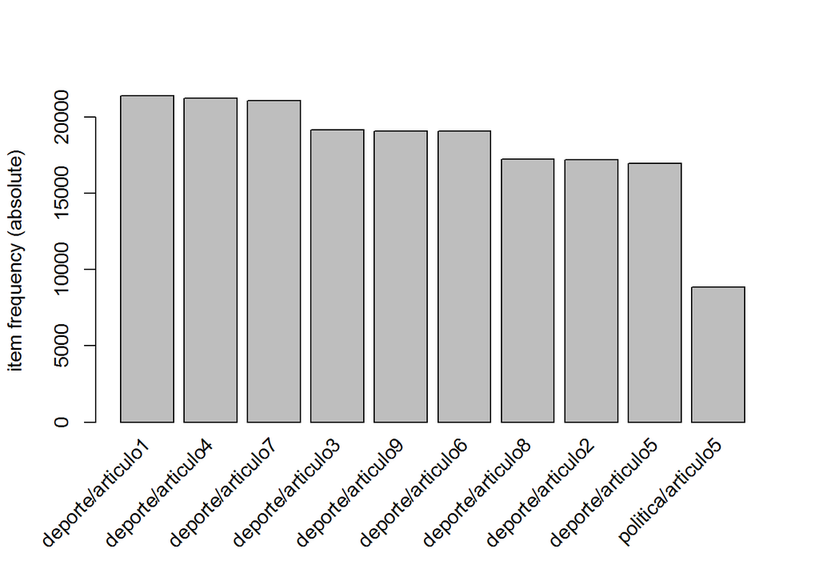

```r
trans <- as(nuevo, "transactions")
itemFrequencyPlot(trans, topN = 10, "absolute")
```